# Simple Event Model Value of Information

# Probalisitc Sensitivity Analysis

```r
load("./psa-toy.Rdata")
select <- dplyr::select
mutate <- dplyr::mutate
Sim <- PSA %>% tbl_df()
Sim <- PSA %>% mutate(iteration=row_number()) %>% select(iteration,cost.A,qaly.A,cost.B,qaly.B,contains(".B"))
Sim2 <- read.csv("../../VOI_SMDM_2016/Metamodeling_SensitivityAnalysis_SMDM2014/PSA.csv")
Strategies<-c("Standard", "Therapy")
#Determine the number of strategies
ndep<-length(Strategies)
#Create vector of variable names
Names <- colnames(Sim)
Parms <- Sim %>% select(-iteration,-cost.A,-cost.B,-qaly.A,-qaly.B,-Strategy.B,-disc_rate.B) %>% data.frame() #Sim2[,(ndep*2+2):dim(Sim2)[2]]
#Get parameter names
paramNames<-colnames(Parms)
indep<-ncol(Parms)
Outcomes <- Sim %>%  select(Standard_cost=cost.A,Standard_eff=qaly.A,Therapy_cost=cost.B,Therapy_eff=qaly.B) %>% data.frame
```

In the simulation file we only have each parameter’s sample and the resulting cost and effectiveness for each of the strategies for each set of the parameters’ realization. We need to construct the **Net Health Benefit (NHB)** for each of the strategies. The NHB for strategy $k$ is defined as
$$\bar{NHB}_k = \bar{E}_k - \bar{C}_k/\lambda ,$$
where $\bar{E}_k$ and $\bar{C}_k$ are the expected effectiveness and cost for strategy $k$, respectively; and $\lambda$ is the willingness-to-pay threshold.

```r
  lambda <- 50000
```

## Calculate NHB For Each Strategy

```r
  Sim$A_NHB <- Sim$qaly.A- Sim$cost.A/lambda
  Sim$B_NHB <- Sim$qaly.B- Sim$cost.B/lambda
  #Save the NHB for each strategy into a new data frame
  NHB <- Sim %>% select(A_NHB,B_NHB)
```

# Linear Metamodel

```r
# Identify the parameters that vary
paramvar <- Sim[,paramNames] %>% summarise_all(function(x) var(x))
paramNames.varying <- names(paramvar)[which(paramvar!=0)]
## Cost ##
YY = "cost.A"
fmla.unstd <- as.formula(paste0(YY,"~",paste0(paramNames.varying,collapse="+")))
fmla.std <- as.formula(paste0(YY,"~",paste0(paste0("scale(",paramNames.varying,")"),collapse="+")))
A.cost.fit <- lm(fmla.unstd, data=Sim)
A.cost.fit.std <- lm(fmla.std,data=Sim)
## Effectiveness ##
YY = "qaly.A"
fmla.unstd <- as.formula(paste0(YY,"~",paste0(paramNames.varying,collapse="+")))
fmla.std <- as.formula(paste0(YY,"~",paste0(paste0("scale(",paramNames.varying,")"),collapse="+")))
A.eff.fit <- lm(fmla.unstd, data=Sim)
A.eff.fit.std <- lm(fmla.std,data=Sim)
## NHB ##
YY = "A_NHB"
fmla.unstd <- as.formula(paste0(YY,"~",paste0(paramNames.varying,collapse="+")))
fmla.std <- as.formula(paste0(YY,"~",paste0(paste0("scale(",paramNames.varying,")"),collapse="+")))
A.nhb.fit <- lm(fmla.unstd, data=Sim)
A.nhb.fit.std <- lm(fmla.std,data=Sim)
```

```r
stargazer::stargazer(A.cost.fit,A.eff.fit,A.nhb.fit,
          title="Regression Coefficients from Metamodels on the Outcomes of Chemotherapy",
          type='html',
          dep.var.caption=" With **unstandardized** predictors ",
          dep.var.labels=c("Cost","Effectiveness","NHB"),
          digits=2,
          digits.extra=1,
          keep.stat=c("rsq","n"),
          notes = c('NHB: Net health benefit  '),
          notes.align = 'l',
          notes.append = FALSE,
          omit.table.layout="#",
          report=c("vc"))
```

**Regression Coefficients from Metamodels on the Outcomes of Chemotherapy**

|  | With **unstandardized** predictors |  |  |
| --- | --- | --- | --- |
|  | Cost | Effectiveness | NHB |
| r_a.B | 145,258.30 | -42.94 | -45.84 |
| r_b.B | 921.55 | -0.35 | -0.37 |
| r_ad.B | -709.00 | -2.25 | -2.24 |
| d_a.B | 0.60 | -2.88 | -2.88 |
| d_b.B | 14.97 | -0.04 | -0.04 |
| rr_t.B | -2,738.21 | 0.81 | 0.87 |
| Constant | 1,877.20 | 36.12 | 36.08 |
| Observations | 4,000 | 4,000 | 4,000 |
| R<sup>2</sup> | 0.99 | 1.00 | 1.00 |
| *Note:* | NHB: Net health benefit |  |  |

```r
stargazer::stargazer(A.cost.fit.std,A.eff.fit.std,A.nhb.fit.std,
          title="Regression Coefficients from Metamodels on the Outcomes of Chemotherapy",
          type='html',
          dep.var.caption=" With **standardized** predictors ",
          dep.var.labels=c("Cost","Effectiveness","NHB"),
          digits=2,
          digits.extra=1,
          keep.stat=c("rsq","n"),
          notes = c('NHB: Net health benefit  '),
          notes.align = 'l',
          notes.append = FALSE,
          omit.table.layout="#",
          report=c("vc"))
```

**Regression Coefficients from Metamodels on the Outcomes of Chemotherapy**

|  | With **standardized** predictors |  |  |
| --- | --- | --- | --- |
|  | Cost | Effectiveness | NHB |
| scale(r_a.B) | 164.06 | -0.05 | -0.05 |
| scale(r_b.B) | 44.29 | -0.02 | -0.02 |
| scale(r_ad.B) | -4.89 | -0.02 | -0.02 |
| scale(d_a.B) | 0.03 | -0.12 | -0.12 |
| scale(d_b.B) | 0.14 | -0.000 | -0.000 |
| scale(rr_t.B) | -136.21 | 0.04 | 0.04 |
| Constant | 1,977.37 | 35.23 | 35.19 |
| Observations | 4,000 | 4,000 | 4,000 |
| R<sup>2</sup> | 0.99 | 1.00 | 1.00 |
| *Note:* | NHB: Net health benefit |  |  |

## One-Way Sensitivity Analysis

```r
Sim.Long <- Sim %>% tbl_df() %>% select(one_of(c("iteration",paramNames.varying,"A_NHB","B_NHB"))) %>% data.frame() %>%
  melt(id.vars=c("iteration",paramNames.varying),measure.vars= c("A_NHB","B_NHB"))
```

Next we define the parameter for which we desire to do the one-way sensitivity analysis and its range.

```r
parm<-'d_a.B'
```

The graph over the parameter’s sample domain looks like

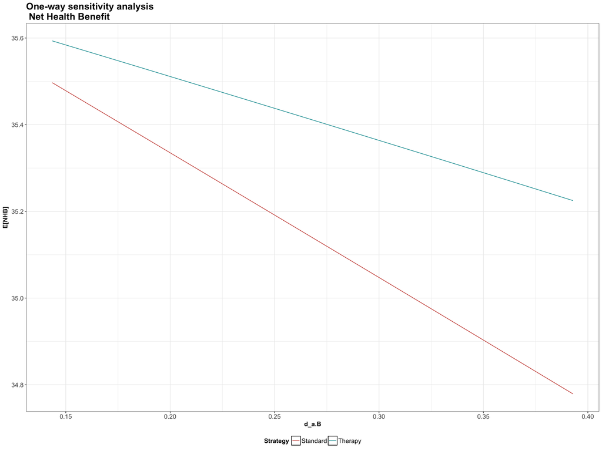

```r
OneWaySA(Strategies,Parms,NHB,parm)
```

# Tornado Diagram

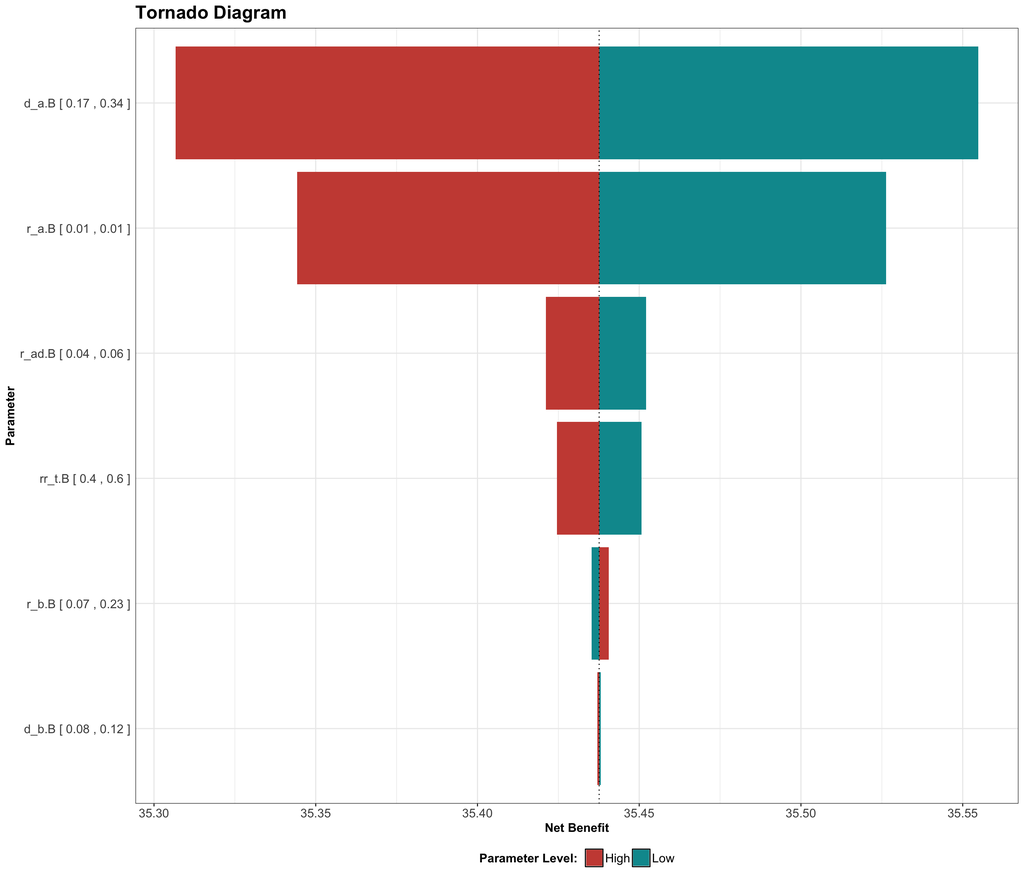

```r
NHB <- NHB %>% data.frame()
Parms <- Parms %>% data.frame()
TornadoOpt(Parms[,paramNames.varying],NHB)
```